# correlation analysis

Feiya Suo

3/13/2022

# Read data

```r
data <- read.csv("/Users/feiyasuo/Documents/GitHub/STOR765_Spring2022_FeiyaSuo/CountyLevel_data.csv")
```

# Descriptive Statistics

In this section, I calculate the descriptive statistics for each variable in the county-level data. The summary of the statistics can be found in the report.

```r
summary(data$available_volunteer)
```

```
##    Min. 1st Qu.  Median    Mean 3rd Qu.    Max.
##    9.00   29.50   53.00   92.36  100.25  853.00
```

```r
sd(data$available_volunteer)
```

```
## [1] 121.8499
```

```r
summary(data$percent_available)
```

```
##      Min.   1st Qu.    Median      Mean   3rd Qu.      Max.
## 0.0002548 0.0006927 0.0009157 0.0012084 0.0014190 0.0041266
```

```r
sd(data$percent_available)
```

```
## [1] 0.0007568692
```

```r
summary(data$volunteered)
```

```
##    Min. 1st Qu.  Median    Mean 3rd Qu.    Max.
##    0.00    0.00    0.00    1.58    1.25   19.00
```

```r
sd(data$volunteered)
```

```
## [1] 3.263449
```

```r
summary(data$percent_volunteered)
```

```
##    Min. 1st Qu.  Median    Mean 3rd Qu.    Max.
## 0.00000 0.00000 0.00000 0.01408 0.02083 0.13889
```

```r
sd(data$percent_volunteered)
```

```
## [1] 0.02392634
```

```r
summary(data$Vaccinated_count)
```

```
##    Min. 1st Qu.  Median    Mean 3rd Qu.    Max.
##    1926   11942   26001   59334   57707  784394
```

```r
sd(data$Vaccinated_count)
```

```
## [1] 110421.7
```

```r
summary(data$Vaccinated.percent)
```

```
##    Min. 1st Qu.  Median    Mean 3rd Qu.    Max.
##  0.3987  0.4687  0.5308  0.5326  0.5854  0.7869
```

```r
sd(data$Vaccinated.percent)
```

```
## [1] 0.07971518
```

```r
summary(data$percent_NP)
```

```
##    Min. 1st Qu.  Median    Mean 3rd Qu.    Max.
## 0.02778 0.07992 0.10417 0.11051 0.12903 0.25000
```

```r
sd(data$percent_NP)
```

```
## [1] 0.04553846
```

```r
summary(data$percent_RN)
```

```
##    Min. 1st Qu.  Median    Mean 3rd Qu.    Max.
##  0.6740  0.7756  0.8555  0.9229  1.0100  1.6667
```

```r
sd(data$percent_RN)
```

```
## [1] 0.2095169
```

```r
summary(data$percent_LPN)
```

```
##    Min. 1st Qu.  Median    Mean 3rd Qu.    Max.
## 0.03279 0.07356 0.10000 0.12095 0.15089 0.36364
```

```r
sd(data$percent_LPN)
```

```
## [1] 0.07162722
```

```r
summary(data$percent_Other)
```

```
##    Min. 1st Qu.  Median    Mean 3rd Qu.    Max.
## 0.02128 0.08022 0.10291 0.12012 0.13597 0.30769
```

```r
sd(data$percent_Other)
```

```
## [1] 0.06472421
```

```r
summary(data$percent_retired)
```

```
##    Min. 1st Qu.  Median    Mean 3rd Qu.    Max.
## 0.02800 0.05530 0.08333 0.09386 0.11809 0.25000
```

```r
sd(data$percent_retired)
```

```
## [1] 0.04892833
```

```r
summary(data$ratio_active)
```

```
##    Min. 1st Qu.  Median    Mean 3rd Qu.    Max.
##  0.8936  0.9545  0.9643  0.9615  0.9731  0.9915
```

```r
sd(data$ratio_active)
```

```
## [1] 0.01837812
```

# Scatterplots

The following figures show the scatter plots between vaccination rates and the variables relevant to volunteer nurses. Each dot represents a datapoint, and the blue line represents the estimated regression line between the two variables. The grey area shows the 95% confidence interval of the estimation.

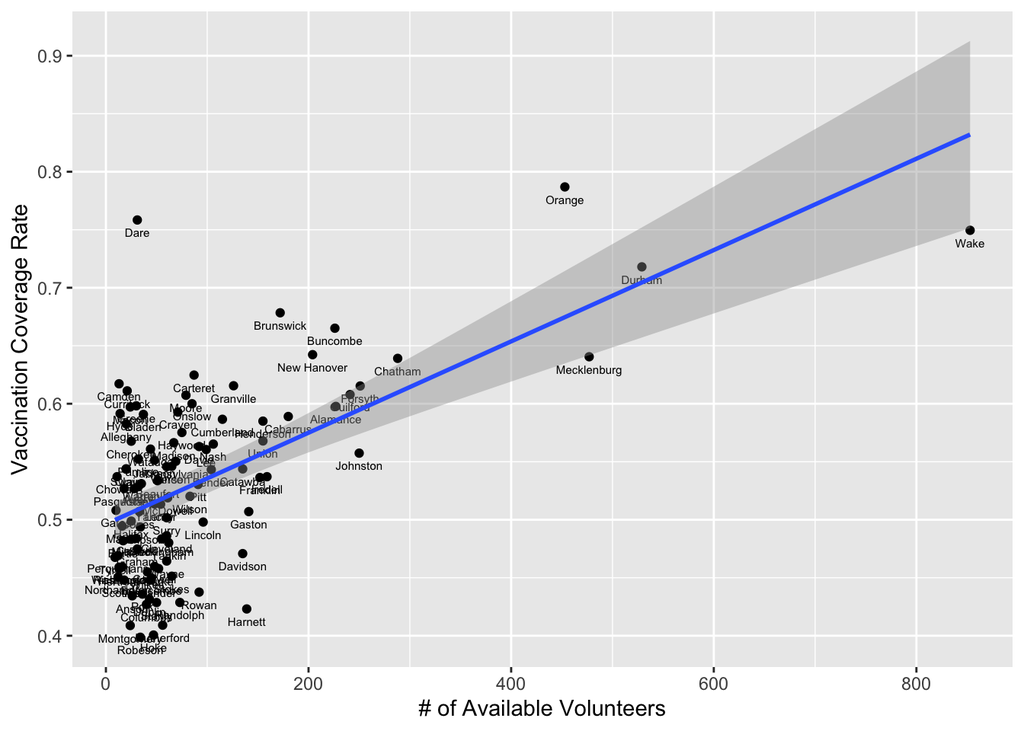

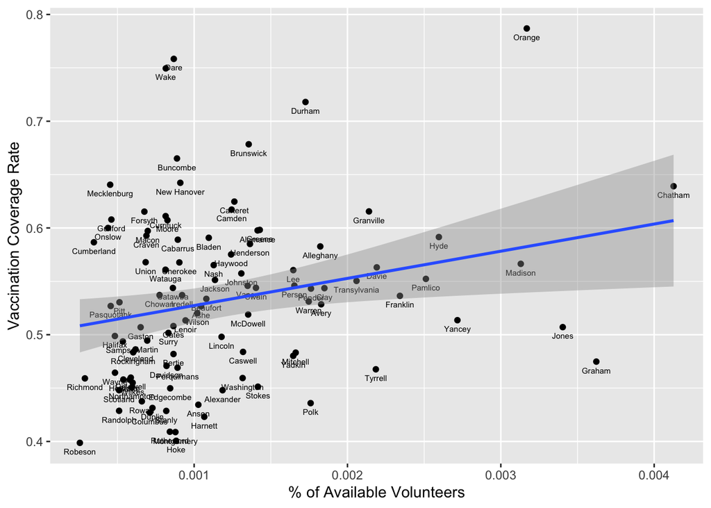

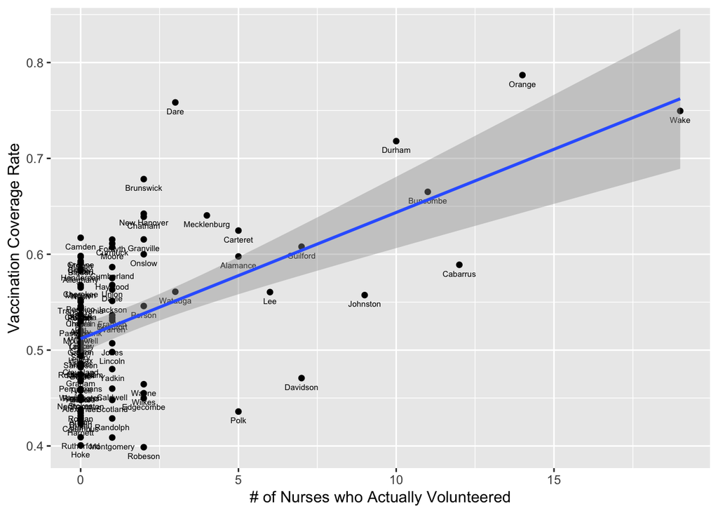

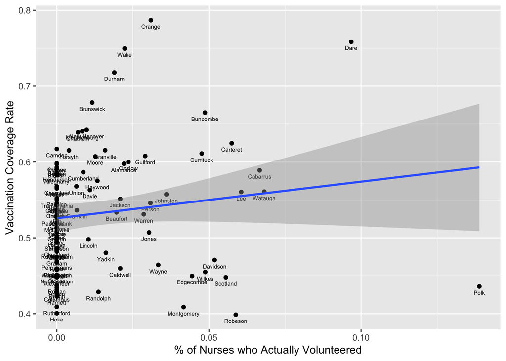

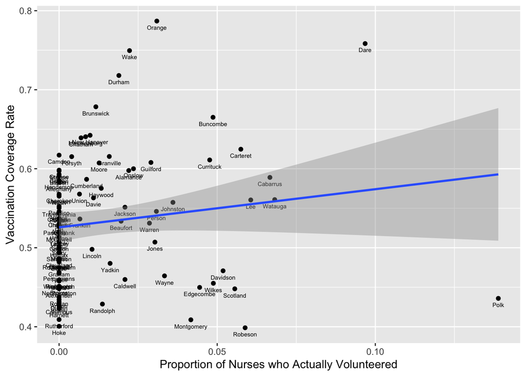